# Kaggle Housing Prices Prediction Competition

Joshua Pasaye

2025-12-15

## Introduction

This R markdown will review my end-to-end process for predicting housing prices in the Kaggle **House Prices - Advanced Regression Techniques** competition. The dataset contains 79 explanatory variables describing (almost) every aspect of residential homes in Ames, Iowa.

**Goal:**

My job to predict the sales price for each house. For each Id in the test set, I must predict the value of the `SalePrice` variable.

**Metric:**

Submissions are evaluated on *Root-Mean-Squared-Error (RMSE)* between the logarithm of the predicted value and the logarithm of the observed sales price.

### Getting Started

First things first, I will need to upload the data. There are two datasets, the test dataset and the training dataset. Since the test dataset will be what I will need to predict, I will only load in the training dataset and do a sanity check to see what I am working with.

```
##   Id MSSubClass MSZoning LotFrontage LotArea Street Alley LotShape LandContour
## 1  1         60       RL          65    8450   Pave  <NA>      Reg         Lvl
## 2  2         20       RL          80    9600   Pave  <NA>      Reg         Lvl
## 3  3         60       RL          68   11250   Pave  <NA>      IR1         Lvl
## 4  4         70       RL          60    9550   Pave  <NA>      IR1         Lvl
## 5  5         60       RL          84   14260   Pave  <NA>      IR1         Lvl
## 6  6         50       RL          85   14115   Pave  <NA>      IR1         Lvl
##   Utilities LotConfig LandSlope Neighborhood Condition1 Condition2 BldgType
## 1    AllPub    Inside       Gtl      CollgCr       Norm       Norm     1Fam
## 2    AllPub       FR2       Gtl      Veenker      Feedr       Norm     1Fam
## 3    AllPub    Inside       Gtl      CollgCr       Norm       Norm     1Fam
## 4    AllPub    Corner       Gtl      Crawfor       Norm       Norm     1Fam
## 5    AllPub       FR2       Gtl      NoRidge       Norm       Norm     1Fam
## 6    AllPub    Inside       Gtl      Mitchel       Norm       Norm     1Fam
##   HouseStyle OverallQual OverallCond YearBuilt YearRemodAdd RoofStyle RoofMatl
```

[output cut: 69 more lines]

There looks be a good mix of character variables and numeric variables. Additionally, there seem to be a good amount of missing values in the dataset. These will be handled very soon.

Next, I will look at the each variables data type (i.e., character/string, integer, numeric, logical, etc.) to determine how I will impute missing variables.

```
## 'data.frame':    1460 obs. of  81 variables:
##  $ Id           : int  1 2 3 4 5 6 7 8 9 10 ...
##  $ MSSubClass   : int  60 20 60 70 60 50 20 60 50 190 ...
##  $ MSZoning     : chr  "RL" "RL" "RL" "RL" ...
##  $ LotFrontage  : int  65 80 68 60 84 85 75 NA 51 50 ...
##  $ LotArea      : int  8450 9600 11250 9550 14260 14115 10084 10382 6120 7420 ...
##  $ Street       : chr  "Pave" "Pave" "Pave" "Pave" ...
##  $ Alley        : chr  NA NA NA NA ...
##  $ LotShape     : chr  "Reg" "Reg" "IR1" "IR1" ...
##  $ LandContour  : chr  "Lvl" "Lvl" "Lvl" "Lvl" ...
##  $ Utilities    : chr  "AllPub" "AllPub" "AllPub" "AllPub" ...
##  $ LotConfig    : chr  "Inside" "FR2" "Inside" "Corner" ...
##  $ LandSlope    : chr  "Gtl" "Gtl" "Gtl" "Gtl" ...
##  $ Neighborhood : chr  "CollgCr" "Veenker" "CollgCr" "Crawfor" ...
##  $ Condition1   : chr  "Norm" "Feedr" "Norm" "Norm" ...
```

[output cut: 67 more lines]

It looks like all of the variables are either a character/string type of variable or an integer type of variable, which makes it easy to manipulate the dataset before training.

Finally, as an initial sanity check, I will determine the number of missing values each column has. That will determine what/if imputation methods I will employ.

```
##            Id    MSSubClass      MSZoning   LotFrontage       LotArea
##             0             0             0           259             0
##        Street         Alley      LotShape   LandContour     Utilities
##             0          1369             0             0             0
##     LotConfig     LandSlope  Neighborhood    Condition1    Condition2
##             0             0             0             0             0
##      BldgType    HouseStyle   OverallQual   OverallCond     YearBuilt
##             0             0             0             0             0
##  YearRemodAdd     RoofStyle      RoofMatl   Exterior1st   Exterior2nd
##             0             0             0             0             0
##    MasVnrType    MasVnrArea     ExterQual     ExterCond    Foundation
##             8             8             0             0             0
##      BsmtQual      BsmtCond  BsmtExposure  BsmtFinType1    BsmtFinSF1
##            37            37            38            37             0
##  BsmtFinType2    BsmtFinSF2     BsmtUnfSF   TotalBsmtSF       Heating
##            38             0             0             0             0
##     HeatingQC    CentralAir    Electrical     X1stFlrSF     X2ndFlrSF
##             0             0             1             0             0
##  LowQualFinSF     GrLivArea  BsmtFullBath  BsmtHalfBath      FullBath
##             0             0             0             0             0
##      HalfBath  BedroomAbvGr  KitchenAbvGr   KitchenQual  TotRmsAbvGrd
##             0             0             0             0             0
##    Functional    Fireplaces   FireplaceQu    GarageType   GarageYrBlt
##             0             0           690            81            81
##  GarageFinish    GarageCars    GarageArea    GarageQual    GarageCond
##            81             0             0            81            81
##    PavedDrive    WoodDeckSF   OpenPorchSF EnclosedPorch    X3SsnPorch
##             0             0             0             0             0
##   ScreenPorch      PoolArea        PoolQC         Fence   MiscFeature
##             0             0          1453          1179          1406
##       MiscVal        MoSold        YrSold      SaleType SaleCondition
##             0             0             0             0             0
##     SalePrice
##             0
```

There are a good amount of missing values throughout the dataset, with the `PoolQC` variable having the highest amount of missing data. To correct for missing values, I will take the *median* value of each numeric variable, and for each character variable, I will put a new category called “None”.

## EDA

### Visualizations

First, I will do some visualizations to see if there are any interesting relationships that could be explored further.

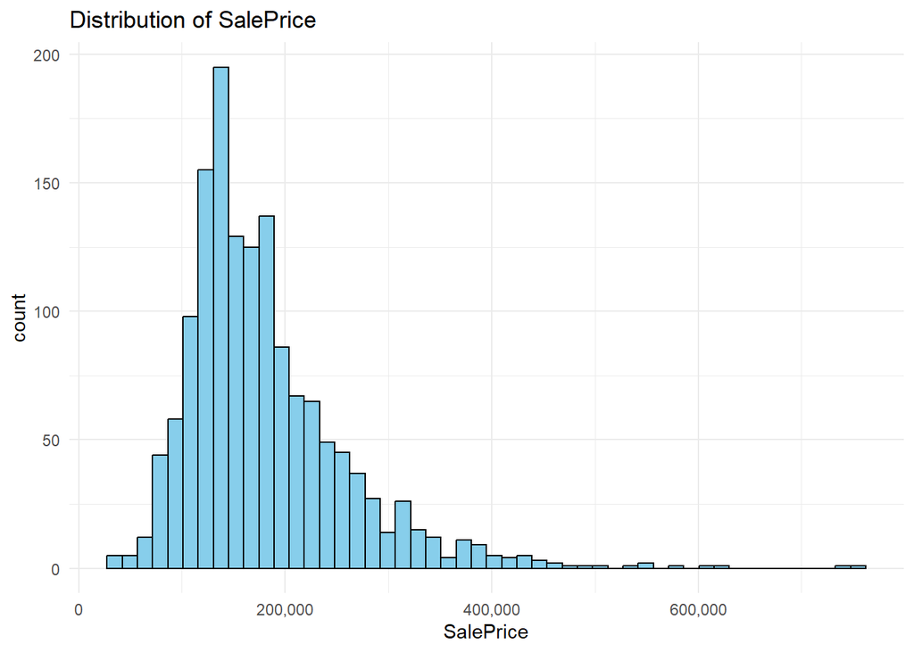

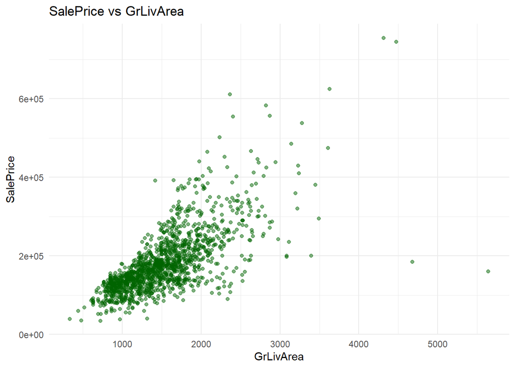

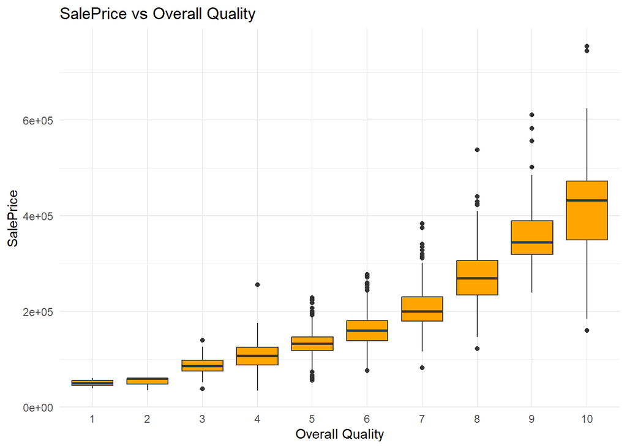

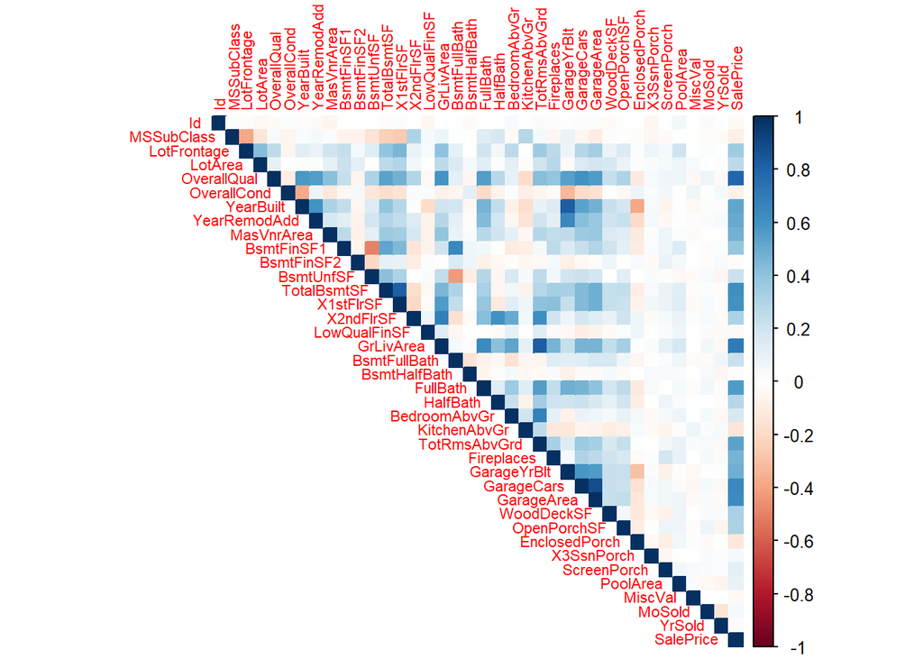

### Statistics

Now, I will look at potential relationships using correlations and other EDA techniques.

```
##        Id           MSSubClass     LotFrontage        LotArea
##  Min.   :   1.0   Min.   : 20.0   Min.   : 21.00   Min.   :  1300
##  1st Qu.: 365.8   1st Qu.: 20.0   1st Qu.: 59.00   1st Qu.:  7554
##  Median : 730.5   Median : 50.0   Median : 69.00   Median :  9478
##  Mean   : 730.5   Mean   : 56.9   Mean   : 70.05   Mean   : 10517
##  3rd Qu.:1095.2   3rd Qu.: 70.0   3rd Qu.: 80.00   3rd Qu.: 11602
##  Max.   :1460.0   Max.   :190.0   Max.   :313.00   Max.   :215245
##                                   NA's   :259
##   OverallQual      OverallCond      YearBuilt     YearRemodAdd
##  Min.   : 1.000   Min.   :1.000   Min.   :1872   Min.   :1950
##  1st Qu.: 5.000   1st Qu.:5.000   1st Qu.:1954   1st Qu.:1967
##  Median : 6.000   Median :5.000   Median :1973   Median :1994
##  Mean   : 6.099   Mean   :5.575   Mean   :1971   Mean   :1985
##  3rd Qu.: 7.000   3rd Qu.:6.000   3rd Qu.:2000   3rd Qu.:2004
##  Max.   :10.000   Max.   :9.000   Max.   :2010   Max.   :2010
##
##    MasVnrArea       BsmtFinSF1       BsmtFinSF2        BsmtUnfSF
##  Min.   :   0.0   Min.   :   0.0   Min.   :   0.00   Min.   :   0.0
##  1st Qu.:   0.0   1st Qu.:   0.0   1st Qu.:   0.00   1st Qu.: 223.0
##  Median :   0.0   Median : 383.5   Median :   0.00   Median : 477.5
##  Mean   : 103.7   Mean   : 443.6   Mean   :  46.55   Mean   : 567.2
##  3rd Qu.: 166.0   3rd Qu.: 712.2   3rd Qu.:   0.00   3rd Qu.: 808.0
##  Max.   :1600.0   Max.   :5644.0   Max.   :1474.00   Max.   :2336.0
##  NA's   :8
##   TotalBsmtSF       X1stFlrSF      X2ndFlrSF     LowQualFinSF
##  Min.   :   0.0   Min.   : 334   Min.   :   0   Min.   :  0.000
##  1st Qu.: 795.8   1st Qu.: 882   1st Qu.:   0   1st Qu.:  0.000
##  Median : 991.5   Median :1087   Median :   0   Median :  0.000
##  Mean   :1057.4   Mean   :1163   Mean   : 347   Mean   :  5.845
##  3rd Qu.:1298.2   3rd Qu.:1391   3rd Qu.: 728   3rd Qu.:  0.000
##  Max.   :6110.0   Max.   :4692   Max.   :2065   Max.   :572.000
##
##    GrLivArea     BsmtFullBath     BsmtHalfBath        FullBath
##  Min.   : 334   Min.   :0.0000   Min.   :0.00000   Min.   :0.000
##  1st Qu.:1130   1st Qu.:0.0000   1st Qu.:0.00000   1st Qu.:1.000
##  Median :1464   Median :0.0000   Median :0.00000   Median :2.000
##  Mean   :1515   Mean   :0.4253   Mean   :0.05753   Mean   :1.565
##  3rd Qu.:1777   3rd Qu.:1.0000   3rd Qu.:0.00000   3rd Qu.:2.000
##  Max.   :5642   Max.   :3.0000   Max.   :2.00000   Max.   :3.000
##
```

[output cut: 25 more lines]

```
##  Min.   :  0.00   Min.   :  0.000   Min.   :    0.00   Min.   : 1.000
##  1st Qu.:  0.00   1st Qu.:  0.000   1st Qu.:    0.00   1st Qu.: 5.000
##  Median :  0.00   Median :  0.000   Median :    0.00   Median : 6.000
##  Mean   : 15.06   Mean   :  2.759   Mean   :   43.49   Mean   : 6.322
##  3rd Qu.:  0.00   3rd Qu.:  0.000   3rd Qu.:    0.00   3rd Qu.: 8.000
##  Max.   :480.00   Max.   :738.000   Max.   :15500.00   Max.   :12.000
##
##      YrSold       SalePrice
##  Min.   :2006   Min.   : 34900
##  1st Qu.:2007   1st Qu.:129975
##  Median :2008   Median :163000
##  Mean   :2008   Mean   :180921
##  3rd Qu.:2009   3rd Qu.:214000
##  Max.   :2010   Max.   :755000
##
```

```
##  LotFrontage        Alley   MasVnrType   MasVnrArea     BsmtQual     BsmtCond
##          259         1369            8            8           37           37
## BsmtExposure BsmtFinType1 BsmtFinType2   Electrical  FireplaceQu   GarageType
##           38           37           38            1          690           81
##  GarageYrBlt GarageFinish   GarageQual   GarageCond       PoolQC        Fence
##           81           81           81           81         1453         1179
##  MiscFeature
##         1406
```

```
##     SalePrice   OverallQual     GrLivArea    GarageCars    GarageArea
##    1.00000000    0.79098160    0.70862448    0.64040920    0.62343144
##   TotalBsmtSF     X1stFlrSF      FullBath  TotRmsAbvGrd     YearBuilt
##    0.61358055    0.60585218    0.56066376    0.53372316    0.52289733
##  YearRemodAdd   GarageYrBlt    MasVnrArea    Fireplaces    BsmtFinSF1
##    0.50710097    0.48636168    0.47749305    0.46692884    0.38641981
##   LotFrontage    WoodDeckSF     X2ndFlrSF   OpenPorchSF      HalfBath
##    0.35179910    0.32441344    0.31933380    0.31585623    0.28410768
##       LotArea  BsmtFullBath     BsmtUnfSF  BedroomAbvGr   ScreenPorch
##    0.26384335    0.22712223    0.21447911    0.16821315    0.11144657
##      PoolArea        MoSold    X3SsnPorch    BsmtFinSF2  BsmtHalfBath
##    0.09240355    0.04643225    0.04458367   -0.01137812   -0.01684415
##       MiscVal            Id  LowQualFinSF        YrSold   OverallCond
##   -0.02118958   -0.02191672   -0.02560613   -0.02892259   -0.07785589
##    MSSubClass EnclosedPorch  KitchenAbvGr
##   -0.08428414   -0.12857796   -0.13590737
```

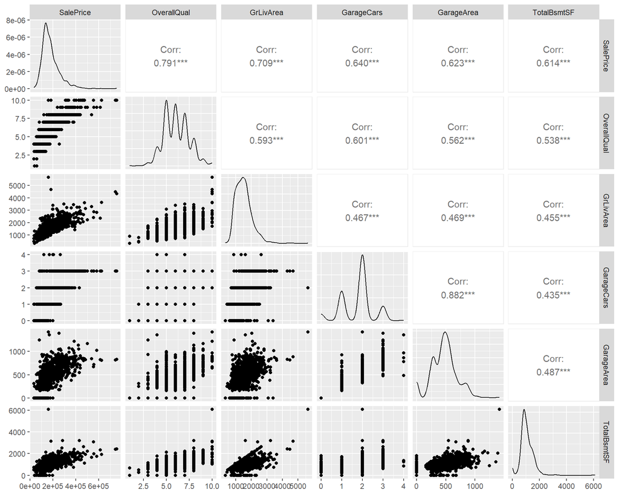

Based on the EDA, `SalePrice` is has a very strong positive correlation `OverallQual` (.79) and the `GrLivArea` (.71) variables, which make sense as the higher overall quality of the home and more living room space, can indicate a larger home and higher price. Additionally, other notable variables that had a strong relationship were: `GarageCars` (0.64), `GarageArea` (0.62), `TotalBsmtSF` (.61), `X1stFlrSF` (.61), and `FullBath` (0.56). These variables indicate that larger living space, storage space, and functional amenities drive value, and will be key variables to start with.

## Data Preparation

### Cleaning dataset

Now, I will separate the data into numeric and categorical variables and then impute the missing values. For the numeric columns, I will impute with the missing with the *median* value. For the character columns, we will add a new category called “None”.

```r
# Define top variables
top_vars <- c("OverallQual", "GrLivArea", "GarageCars",
              "GarageArea", "TotalBsmtSF", "X1stFlrSF", "FullBath", "SalePrice")

df_top <- df[, top_vars]


# Separate numeric columns
numeric_cols <- df_top %>%
  select(where(is.numeric)) %>%
  select(-SalePrice) %>% # exclude Id & SalePrice
  names()

# Impute data
numeric_cols <- setdiff(names(df_top), "SalePrice")

for (col in numeric_cols) {
  df_top[[col]][is.na(df_top[[col]])] <- median(df_top[[col]], na.rm = TRUE)
}

# Print final dataset
print(head(df_top))
```

```
##   OverallQual GrLivArea GarageCars GarageArea TotalBsmtSF X1stFlrSF FullBath
## 1           7      1710          2        548         856       856        2
## 2           6      1262          2        460        1262      1262        2
## 3           7      1786          2        608         920       920        2
## 4           7      1717          3        642         756       961        1
## 5           8      2198          3        836        1145      1145        2
## 6           5      1362          2        480         796       796        1
##   SalePrice
## 1    208500
## 2    181500
## 3    223500
## 4    140000
## 5    250000
## 6    143000
```

We removed all the missing values from the dataset!

### Scale data

```r
# Set up scaling
bounds <- list()

for (col in numeric_cols) {
  Q1 <- quantile(df_top[[col]], 0.25)
  Q3 <- quantile(df_top[[col]], 0.75)
  IQR_val <- Q3 - Q1
  lower <- Q1 - 1.5 * IQR_val
  upper <- Q3 + 1.5 * IQR_val
  bounds[[col]] <- c(lower = lower, upper = upper)

  # Truncate
  df_top[[col]] <- pmin(pmax(df_top[[col]], lower), upper)

  # Normalize
  df_top[[paste0("nor_", col)]] <- (df_top[[col]] - lower) / (upper - lower)
}
```

```r
# Split dataset into test and validations
set.seed(123)
train_index <- createDataPartition(df_top$SalePrice, p = 0.8, list = FALSE)
train_train <- df_top[train_index, ]
train_val   <- df_top[-train_index, ]

# Prepare predictors & target
X_train <- train_train[, paste0("nor_", numeric_cols)]
y_train <- train_train$SalePrice
X_train_mat <- as.matrix(X_train) # LASSO and XGBoosting

X_val <- train_val[, paste0("nor_", numeric_cols)]
y_val <- train_val$SalePrice
X_val_mat <- as.matrix(X_val) # LASSO and XGBoosting

# Log y variables
y_train_log <- log(y_train)
y_val_log <- log(y_val)
```

Now we are ready to set-up the models!

## Models

With all the data preparation complete, I can begin to set-up the models. I will be comparing the following models to determine which model performed the best:

- `Linear Regression`
- `LASSO`
- `Random Forest`
- `Gradient Boosting`
- `XGBoosting`

### Linear Regression

```r
# Set seed
set.seed(123)

# Set up control to compare all models
ctrl <- trainControl(method = "cv", number = 5)

# Fit model
lm_model <- train(
  x = X_train,
  y = y_train_log,
  method = "lm",
  trControl = ctrl
  )

# Predict model
pred_lm <- predict(lm_model, X_val)

# Metrics
lm_rmse <- RMSE(pred_lm[!is.na(pred_lm)], y_val_log[!is.na(pred_lm)])
print(lm_rmse)
```

```
## [1] 0.16975
```

```r
# Feature importance
summary(lm_model)
```

```
##
## Call:
## lm(formula = .outcome ~ ., data = dat)
##
## Residuals:
##      Min       1Q   Median       3Q      Max
## -1.09256 -0.07884  0.01777  0.10738  0.56300
##
## Coefficients:
##                 Estimate Std. Error t value Pr(>|t|)
## (Intercept)     10.72801    0.02205 486.571  < 2e-16 ***
## nor_OverallQual  0.93476    0.04378  21.352  < 2e-16 ***
## nor_GrLivArea    0.58275    0.04079  14.287  < 2e-16 ***
## nor_GarageCars   0.27527    0.06244   4.408 1.14e-05 ***
## nor_GarageArea   0.16957    0.05279   3.212  0.00135 **
## nor_TotalBsmtSF  0.39422    0.04532   8.700  < 2e-16 ***
## nor_X1stFlrSF    0.02572    0.05129   0.502  0.61609
## nor_FullBath     0.10947    0.04983   2.197  0.02821 *
## ---
## Signif. codes:  0 '***' 0.001 '**' 0.01 '*' 0.05 '.' 0.1 ' ' 1
##
## Residual standard error: 0.1704 on 1161 degrees of freedom
## Multiple R-squared:  0.8182, Adjusted R-squared:  0.8171
## F-statistic: 746.6 on 7 and 1161 DF,  p-value: < 2.2e-16
```

### LASSO

Next, I will be training and testing the **LASSO regression** model.

```r
# Set seed
set.seed(123)

# Fit model
cv_lasso <- cv.glmnet(
  x = X_train_mat,
  y = y_train_log,
  alpha = 1,       # alpha = 1 -> LASSO
  nfolds = 5
)

# Best lambda
best_lambda <- cv_lasso$lambda.min

# Fit final model
lasso_model <- glmnet(
  x = X_train_mat,
  y = y_train_log,
  alpha = 1,
  lambda = best_lambda
)

# Predict model
pred_lasso <- predict(lasso_model, X_val_mat)

# Metrics
lasso_rmse <- RMSE(pred_lasso, y_val_log)
print(lasso_rmse)
```

```
## [1] 0.169488
```

```r
# Feature importance
lasso_coefs <- as.matrix(coef(lasso_model))
print(lasso_coefs)
```

```
##                         s0
## (Intercept)     10.7368980
## nor_OverallQual  0.9330867
## nor_GrLivArea    0.5803423
## nor_GarageCars   0.2763161
## nor_GarageArea   0.1658389
## nor_TotalBsmtSF  0.3908241
## nor_X1stFlrSF    0.0240851
## nor_FullBath     0.1037959
```

### Random Forest

Next, I will be training and testing the **Random Forest** model.

```r
# Set seed
set.seed(123)

# Fit model
rf_model <- randomForest(x = X_train, y = y_train_log, ntree = 500)

# Predict model
rf_pred <- predict(rf_model, X_val)

# Metrics
rf_rmse <- RMSE(rf_pred, y_val_log)
print(rf_rmse)
```

```
## [1] 0.1698521
```

```r
# Plot feature importance
print(importance(rf_model))
```

```
##                 IncNodePurity
## nor_OverallQual      49.56373
## nor_GrLivArea        38.16827
## nor_GarageCars       19.49799
## nor_GarageArea       22.79952
## nor_TotalBsmtSF      19.99736
## nor_X1stFlrSF        13.82372
## nor_FullBath         14.66001
```

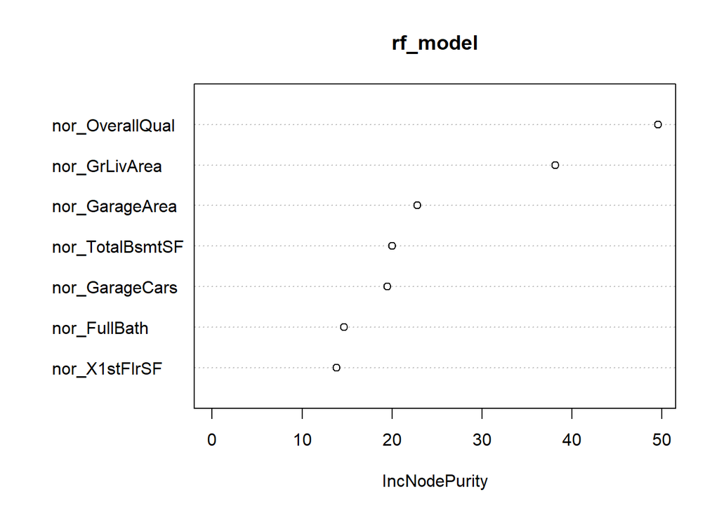

```r
varImpPlot(rf_model)
```

### Gradient Boosting

Next, I will be training and testing the **Gradient Boosting** model.

```r
# Set seed
set.seed(123)

# Combine X_train and log target
train_data <- cbind(X_train, SalePrice_log = y_train_log)

# Fit GBM
gbm_model <- gbm(SalePrice_log ~ ., data = train_data,
                 distribution = "gaussian",
                 n.trees = 5000,
                 interaction.depth = 4,
                 shrinkage = 0.01,
                 cv.folds = 5,
                 n.cores = 1)
```

```
## CV: 1
## CV: 2
## CV: 3
## CV: 4
## CV: 5
```

```r
# Best iteration
best_iter <- gbm.perf(gbm_model, method = "cv")
```

[figure not shown]

```r
# Predict on validation
gbm_pred_val <- predict(gbm_model, X_val, n.trees = best_iter)
gbm_rmse <- RMSE(gbm_pred_val, y_val_log)
print(gbm_rmse)
```

```
## [1] 0.1737498
```

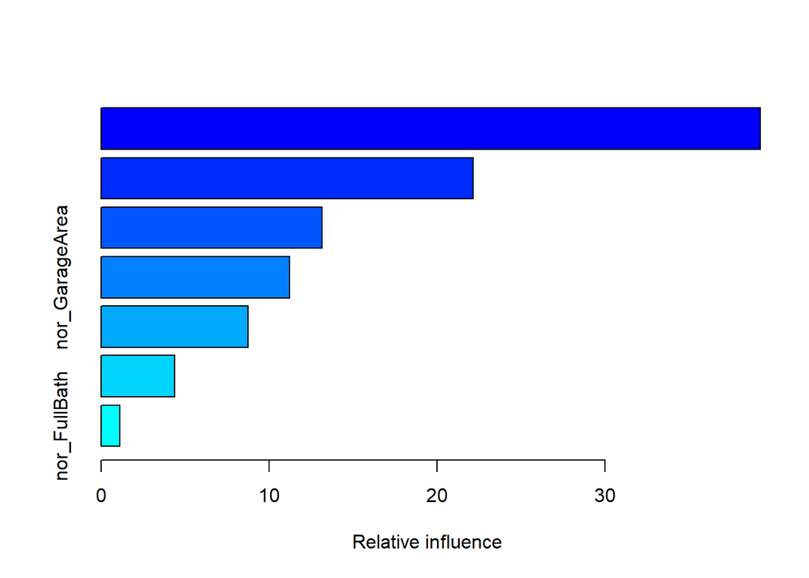

```
##                             var   rel.inf
## nor_OverallQual nor_OverallQual 39.226998
## nor_GrLivArea     nor_GrLivArea 22.154559
## nor_TotalBsmtSF nor_TotalBsmtSF 13.161619
## nor_GarageArea   nor_GarageArea 11.234844
## nor_X1stFlrSF     nor_X1stFlrSF  8.739565
## nor_GarageCars   nor_GarageCars  4.356924
## nor_FullBath       nor_FullBath  1.125491
```

```r
# Feature importance
summary(gbm_model)
```

### XGBoosting

Next, I will be training and testing the **XGBoosting** model.

```r
# Set seed
set.seed(123)

# Fit model
xgb_model <- xgboost(
  x = X_train_mat,
  y = y_train_log,
  nrounds = 500,
  max_depth = 4,
  learning_rate = 0.05,
  objective = "reg:squarederror"
)

# Predict model
xgb_pred <- predict(xgb_model, X_val_mat)

# Metrics
xgb_rmse <- RMSE(xgb_pred, y_val_log)
print(xgb_rmse)
```

```
## [1] 0.1767609
```

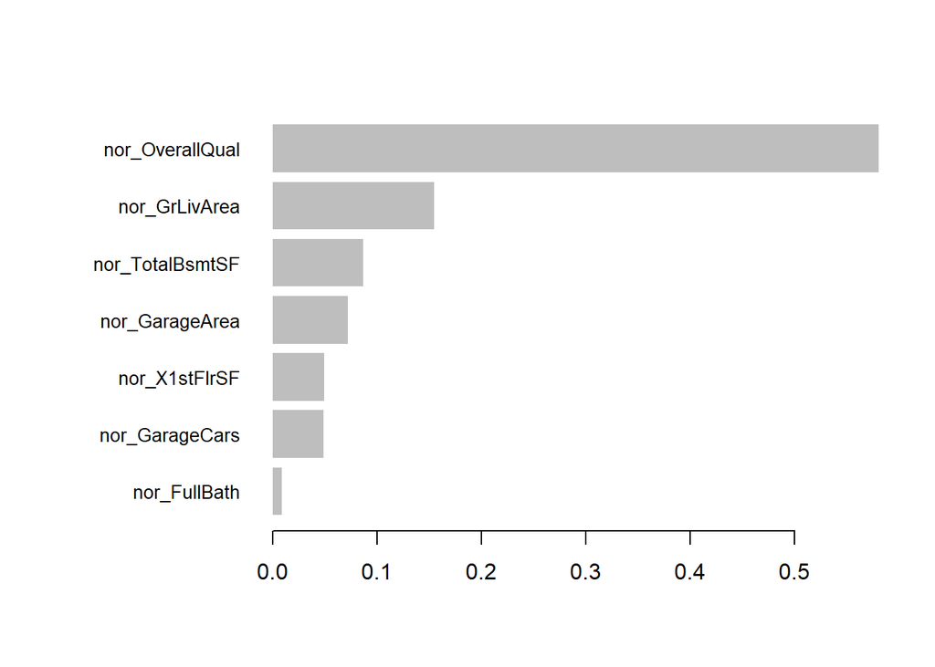

```r
# Plot feature importance
importance <- xgb.importance(feature_names = colnames(X_train_mat), model = xgb_model)
xgb.plot.importance(importance_matrix = importance)
```

## Conclusion

Now, I will compare all the RMSE’s from each model to determine which one was the most accurate. Additionally, I will be using the test dataset for final analysis and prepare my submission to the Kaggle competition.

```r
# Compare RMSEs
results <- data.frame(
  Model = c("Linear Regression", "LASSO", "Random Forest", "Gradient Boosting", "XGBoost"),
  RMSE  = c(lm_rmse, lasso_rmse, rf_rmse, gbm_rmse, xgb_rmse)
)

print(results)
```

```
##               Model      RMSE
## 1 Linear Regression 0.1697500
## 2             LASSO 0.1694880
## 3     Random Forest 0.1698521
## 4 Gradient Boosting 0.1737498
## 5           XGBoost 0.1767609
```

## Submission

```r
# Set seed
set.seed(123)

# Load test dataset
test_df <- read.csv("C:\\Users\\joshp\\OneDrive\\Documents\\Kaggle\\House Price competition\\test.csv")

# Keep only top numeric variables
numeric_cols <- c("OverallQual", "GrLivArea", "GarageCars",
                  "GarageArea", "TotalBsmtSF", "X1stFlrSF", "FullBath")

test_df_top <- test_df[, numeric_cols]

# Impute missing values using training medians
for(col in numeric_cols){
  median_val <- median(df_top[[col]], na.rm = TRUE)
  test_df_top[[col]][is.na(test_df_top[[col]])] <- median_val
}

# Truncate using training bounds
for(col in numeric_cols){
  lower <- bounds[[col]]["lower"]
  upper <- bounds[[col]]["upper"]

  # If bounds are NA (or NULL), replace with min/max from training data
  if(is.na(lower)) lower <- min(df_top[[col]], na.rm = TRUE)
  if(is.na(upper)) upper <- max(df_top[[col]], na.rm = TRUE)

  # Make lower bound realistic for counts
  if(!is.na(lower) && lower < 0) lower <- 0

  # Truncate
  test_df_top[[col]] <- pmin(pmax(test_df_top[[col]], lower), upper)
}

# Normalize
for(col in numeric_cols){
  lower <- bounds[[col]]["lower"]
  upper <- bounds[[col]]["upper"]

  # fallback if NA
  if(is.na(lower)) lower <- min(df_top[[col]], na.rm = TRUE)
  if(is.na(upper)) upper <- max(df_top[[col]], na.rm = TRUE)

  range_val <- upper - lower
  test_df_top[[paste0("nor_", col)]] <- (test_df_top[[col]] - lower) / range_val
}

# Keep only normalized columns for prediction
X_test <- test_df_top[, paste0("nor_", numeric_cols)]

# GBM test
pred_test_log <- predict(gbm_model, newdata = X_test, n.trees = best_iter)
pred_test <- exp(pred_test_log)

# Create Kaggle submission
submission <- data.frame(
  Id = test_df$Id,
  SalePrice = pred_test
)

write.csv(submission, "submission.csv", row.names = FALSE)
```